# Importing Data in R (Part 1)

William Surles

2017-07-05

> This document was updated on **2017-07-10**.

# Introduction

- Course notes for [Importing Data in R (Part 1)](https://www.datacamp.com/courses/importing-data-in-r-part-1)

## Whats Covered

- Importing data from flat files with utils
  - `read.csv`, `read.delim`, `read.table`
  - `stringsAsFactors`, column classes, other arguments
- `readr` & `data.table`
  - `read_csv`, `read_tsv`, `read_delim`
  - skip, n_max, col_types and collectors
  - fread from data.table package
- Importing Excel data
  - `readxl` - listing and importing sheets, column names ans skip
  - `gdata` - `read.xls`
- Reporducible Excel work with XLConnect

## Additional Resources

- [R utils package documentation](https://stat.ethz.ch/R-manual/R-devel/library/utils/html/00Index.html)
- [readr vignette](https://cran.r-project.org/web/packages/readr/vignettes/readr.html)
- [readr package pdf](https://cran.r-project.org/web/packages/readr/readr.pdf)
- [XLConnect vignette](https://cran.r-project.org/web/packages/XLConnect/vignettes/XLConnect.pdf)
- [rio vignette](https://cran.r-project.org/web/packages/rio/vignettes/rio.html)

# Importing data from flat files with utils

## read.csv

- I created the simming_pools.csv file
- I used `dput` in the course workspace to get the code to create the dataframe here then saved it with `write_csv`
- I will do this with all flat files that are needed for the exercises here

```r
## dir functions lets us see what is in the workinig directory
dir('data/')
```

```
## [1] "swimming_pools.csv"
```

```r
# Import swimming_pools.csv: pools
pools <- read.csv('data/swimming_pools.csv')

# Print the structure of pools
str(pools)
```

```
## 'data.frame':    20 obs. of  4 variables:
##  $ Name     : Factor w/ 20 levels "Acacia Ridge Leisure Centre",..: 1 2 3 4 5 6 19 7 8 9 ...
##  $ Address  : Factor w/ 20 levels "1 Fairlead Crescent, Manly",..: 5 20 18 10 9 11 6 15 12 17 ...
##  $ Latitude : num  -27.6 -27.6 -27.6 -27.5 -27.4 ...
##  $ Longitude: num  153 153 153 153 153 ...
```

## sringsAsFactors

- We rarely want string to be factor, so we always need to set this to false when using the utils `read.csv` or other read functions
  - With readr functions it is set to FALSE by default.

```r
# Import swimming_pools.csv correctly: pools
pools <- read.csv("data/swimming_pools.csv", stringsAsFactors=F)

# Check the structure of pools
str(pools)
```

```
## 'data.frame':    20 obs. of  4 variables:
##  $ Name     : chr  "Acacia Ridge Leisure Centre" "Bellbowrie Pool" "Carole Park" "Centenary Pool (inner City)" ...
##  $ Address  : chr  "1391 Beaudesert Road, Acacia Ridge" "Sugarwood Street, Bellbowrie" "Cnr Boundary Road and Waterford Road Wacol" "400 Gregory Terrace, Spring Hill" ...
##  $ Latitude : num  -27.6 -27.6 -27.6 -27.5 -27.4 ...
##  $ Longitude: num  153 153 153 153 153 ...
```

## Any changes?

```r
## How many variables in the resulting pools data frame have different types if you specify the stringsAsFactors argument differently?

# Option A
pools <- read.csv("data/swimming_pools.csv", stringsAsFactors = TRUE)
str(pools)
```

```
## 'data.frame':    20 obs. of  4 variables:
##  $ Name     : Factor w/ 20 levels "Acacia Ridge Leisure Centre",..: 1 2 3 4 5 6 19 7 8 9 ...
##  $ Address  : Factor w/ 20 levels "1 Fairlead Crescent, Manly",..: 5 20 18 10 9 11 6 15 12 17 ...
##  $ Latitude : num  -27.6 -27.6 -27.6 -27.5 -27.4 ...
##  $ Longitude: num  153 153 153 153 153 ...
```

```r
# Option B
pools <- read.csv("data/swimming_pools.csv", stringsAsFactors = FALSE)
str(pools)
```

```
## 'data.frame':    20 obs. of  4 variables:
##  $ Name     : chr  "Acacia Ridge Leisure Centre" "Bellbowrie Pool" "Carole Park" "Centenary Pool (inner City)" ...
##  $ Address  : chr  "1391 Beaudesert Road, Acacia Ridge" "Sugarwood Street, Bellbowrie" "Cnr Boundary Road and Waterford Road Wacol" "400 Gregory Terrace, Spring Hill" ...
##  $ Latitude : num  -27.6 -27.6 -27.6 -27.5 -27.4 ...
##  $ Longitude: num  153 153 153 153 153 ...
```

- `stingsAsFactors` will impact any field that has strings.
  - In this case its the Name and Address fields

## read.delim

```r
# Import hotdogs.txt: hotdogs
hotdogs <- read.delim("data/hotdogs.txt", header=F)

# Summarize hotdogs
summary(hotdogs)
```

```
##        V1           V2              V3
##  Beef   :20   Min.   : 86.0   Min.   :144.0
##  Meat   :17   1st Qu.:132.0   1st Qu.:362.5
##  Poultry:17   Median :145.0   Median :405.0
##               Mean   :145.4   Mean   :424.8
##               3rd Qu.:172.8   3rd Qu.:503.5
##               Max.   :195.0   Max.   :645.0
```

## read.table

```r
# Path to the hotdogs.txt file: path
path <- file.path("data", "hotdogs.txt")

# Import the hotdogs.txt file: hotdogs
hotdogs <- read.table(path,
                      sep = "\t",
                      col.names = c("type", "calories", "sodium"))

# Call head() on hotdogs
head(hotdogs)
```

```
##   type calories sodium
## 1 Beef      186    495
## 2 Beef      181    477
## 3 Beef      176    425
## 4 Beef      149    322
## 5 Beef      184    482
## 6 Beef      190    587
```

## Arguments

```r
# Finish the read.delim() call
hotdogs <- read.delim("data/hotdogs.txt", header = F, col.names = c("type", "calories", "sodium"))
head(hotdogs)
```

```
##   type calories sodium
## 1 Beef      186    495
## 2 Beef      181    477
## 3 Beef      176    425
## 4 Beef      149    322
## 5 Beef      184    482
## 6 Beef      190    587
```

```r
# Select the hot dog with the least calories: lily
lily <- hotdogs[which.min(hotdogs$calories), ]

# Select the observation with the most sodium: tom
tom <- hotdogs[which.max(hotdogs$sodium), ]

# Print lily and tom
lily
```

```
##       type calories sodium
## 50 Poultry       86    358
```

```r
tom
```

```
##    type calories sodium
## 15 Beef      190    645
```

## Column classes

- using `NULL` in the colClasses vector will skip that column

```r
# Previous call to import hotdogs.txt
hotdogs <- read.delim("data/hotdogs.txt", header = FALSE, col.names = c("type", "calories", "sodium"))

# Display structure of hotdogs
str(hotdogs)
```

```
## 'data.frame':    54 obs. of  3 variables:
##  $ type    : Factor w/ 3 levels "Beef","Meat",..: 1 1 1 1 1 1 1 1 1 1 ...
##  $ calories: int  186 181 176 149 184 190 158 139 175 148 ...
##  $ sodium  : int  495 477 425 322 482 587 370 322 479 375 ...
```

```r
# Edit the colClasses argument to import the data correctly: hotdogs2
hotdogs2 <- read.delim("data/hotdogs.txt", header = FALSE,
                       col.names = c("type", "calories", "sodium"),
                       colClasses = c("factor", "NULL","numeric"))


# Display structure of hotdogs2
str(hotdogs2)
```

```
## 'data.frame':    54 obs. of  2 variables:
##  $ type  : Factor w/ 3 levels "Beef","Meat",..: 1 1 1 1 1 1 1 1 1 1 ...
##  $ sodium: num  495 477 425 322 482 587 370 322 479 375 ...
```

## Final Thoughts

- Read.csv and read.delim wrap read.table

# readr & data.table

## read_csv

```r
## readr is already loaded

# Import potatoes.csv with read_csv(): potatoes
potatoes <- read_csv("data/potatoes.csv")
potatoes
```

```
## # A tibble: 160 x 8
##     area  temp  size storage method texture flavor moistness
##    <int> <int> <int>   <int>  <int>   <dbl>  <dbl>     <dbl>
##  1     1     1     1       1      1     2.9    3.2       3.0
##  2     1     1     1       1      2     2.3    2.5       2.6
##  3     1     1     1       1      3     2.5    2.8       2.8
##  4     1     1     1       1      4     2.1    2.9       2.4
##  5     1     1     1       1      5     1.9    2.8       2.2
##  6     1     1     1       2      1     1.8    3.0       1.7
##  7     1     1     1       2      2     2.6    3.1       2.4
##  8     1     1     1       2      3     3.0    3.0       2.9
##  9     1     1     1       2      4     2.2    3.2       2.5
## 10     1     1     1       2      5     2.0    2.8       1.9
## # ... with 150 more rows
```

## read_tsv

```r
# Column names
col_names_potatoes <- c("area", "temp", "size", "storage", "method",
                "texture", "flavor", "moistness")

# Import potatoes.txt: potatoes
potatoes <- read_tsv("data/potatoes.txt", col_names = col_names_potatoes)

# Call head() on potatoes
head(potatoes)
```

```
## # A tibble: 6 x 8
##    area  temp  size storage method texture flavor moistness
##   <int> <int> <int>   <int>  <int>   <dbl>  <dbl>     <dbl>
## 1     1     1     1       1      1     2.9    3.2       3.0
## 2     1     1     1       1      2     2.3    2.5       2.6
## 3     1     1     1       1      3     2.5    2.8       2.8
## 4     1     1     1       1      4     2.1    2.9       2.4
## 5     1     1     1       1      5     1.9    2.8       2.2
## 6     1     1     1       2      1     1.8    3.0       1.7
```

read_delim

```r
# Column names
col_names_potatoes <- c("area", "temp", "size", "storage", "method",
                "texture", "flavor", "moistness")

# Import potatoes.txt using read_delim(): potatoes
potatoes <- read_delim("data/potatoes.txt", delim="\t", col_names = col_names_potatoes)

# Print out potatoes
potatoes
```

```
## # A tibble: 160 x 8
##     area  temp  size storage method texture flavor moistness
##    <int> <int> <int>   <int>  <int>   <dbl>  <dbl>     <dbl>
##  1     1     1     1       1      1     2.9    3.2       3.0
##  2     1     1     1       1      2     2.3    2.5       2.6
##  3     1     1     1       1      3     2.5    2.8       2.8
##  4     1     1     1       1      4     2.1    2.9       2.4
##  5     1     1     1       1      5     1.9    2.8       2.2
##  6     1     1     1       2      1     1.8    3.0       1.7
##  7     1     1     1       2      2     2.6    3.1       2.4
##  8     1     1     1       2      3     3.0    3.0       2.9
##  9     1     1     1       2      4     2.2    3.2       2.5
## 10     1     1     1       2      5     2.0    2.8       1.9
## # ... with 150 more rows
```

## skip and n_max

```r
# Column names
col_names_potatoes <- c("area", "temp", "size", "storage", "method",
                "texture", "flavor", "moistness")

# Import 5 observations from potatoes.txt: potatoes_fragment
potatoes_fragment <- read_tsv("data/potatoes.txt", skip = 6, n_max = 5, col_names = col_names_potatoes)

potatoes_fragment
```

```
## # A tibble: 5 x 8
##    area  temp  size storage method texture flavor moistness
##   <int> <int> <int>   <int>  <int>   <dbl>  <dbl>     <dbl>
## 1     1     1     1       2      2     2.6    3.1       2.4
## 2     1     1     1       2      3     3.0    3.0       2.9
## 3     1     1     1       2      4     2.2    3.2       2.5
## 4     1     1     1       2      5     2.0    2.8       1.9
## 5     1     1     1       3      1     1.8    2.6       1.5
```

## col_types

```r
# Column names
col_names_potatoes <- c("area", "temp", "size", "storage", "method",
                "texture", "flavor", "moistness")

# Import all data, but force all columns to be character: potatoes_char
potatoes_char <- read_tsv("data/potatoes.txt", col_types = "cccccccc", col_names = col_names_potatoes)

# Print out structure of potatoes_char
str(potatoes_char)
```

```
## Classes 'tbl_df', 'tbl' and 'data.frame':    160 obs. of  8 variables:
##  $ area     : chr  "1" "1" "1" "1" ...
##  $ temp     : chr  "1" "1" "1" "1" ...
##  $ size     : chr  "1" "1" "1" "1" ...
##  $ storage  : chr  "1" "1" "1" "1" ...
##  $ method   : chr  "1" "2" "3" "4" ...
##  $ texture  : chr  "2.9" "2.3" "2.5" "2.1" ...
##  $ flavor   : chr  "3.2" "2.5" "2.8" "2.9" ...
##  $ moistness: chr  "3" "2.6" "2.8" "2.4" ...
##  - attr(*, "spec")=List of 2
##   ..$ cols   :List of 8
##   .. ..$ area     : list()
##   .. .. ..- attr(*, "class")= chr  "collector_character" "collector"
##   .. ..$ temp     : list()
##   .. .. ..- attr(*, "class")= chr  "collector_character" "collector"
##   .. ..$ size     : list()
##   .. .. ..- attr(*, "class")= chr  "collector_character" "collector"
##   .. ..$ storage  : list()
##   .. .. ..- attr(*, "class")= chr  "collector_character" "collector"
##   .. ..$ method   : list()
##   .. .. ..- attr(*, "class")= chr  "collector_character" "collector"
##   .. ..$ texture  : list()
##   .. .. ..- attr(*, "class")= chr  "collector_character" "collector"
##   .. ..$ flavor   : list()
##   .. .. ..- attr(*, "class")= chr  "collector_character" "collector"
##   .. ..$ moistness: list()
##   .. .. ..- attr(*, "class")= chr  "collector_character" "collector"
##   ..$ default: list()
##   .. ..- attr(*, "class")= chr  "collector_guess" "collector"
##   ..- attr(*, "class")= chr "col_spec"
```

## col_types with collectors

```r
# Import without col_types
hotdogs <- read_tsv("data/hotdogs.txt", col_names = c("type", "calories", "sodium"))

# Display the summary of hotdogs
summary(hotdogs)
```

```
##      type              calories         sodium
##  Length:54          Min.   : 86.0   Min.   :144.0
##  Class :character   1st Qu.:132.0   1st Qu.:362.5
##  Mode  :character   Median :145.0   Median :405.0
##                     Mean   :145.4   Mean   :424.8
##                     3rd Qu.:172.8   3rd Qu.:503.5
##                     Max.   :195.0   Max.   :645.0
```

```r
# The collectors you will need to import the data
fac <- col_factor(levels = c("Beef", "Meat", "Poultry"))
int <- col_integer()

# Edit the col_types argument to import the data correctly: hotdogs_factor
hotdogs_factor <- read_tsv("data/hotdogs.txt",
                           col_names = c("type", "calories", "sodium"),
                           col_types = list(fac, int, int))

# Display the summary of hotdogs_factor
summary(hotdogs_factor)
```

```
##       type       calories         sodium
##  Beef   :20   Min.   : 86.0   Min.   :144.0
##  Meat   :17   1st Qu.:132.0   1st Qu.:362.5
##  Poultry:17   Median :145.0   Median :405.0
##               Mean   :145.4   Mean   :424.8
##               3rd Qu.:172.8   3rd Qu.:503.5
##               Max.   :195.0   Max.   :645.0
```

- Another way to do this is to just change the one column to a factor afterwards
  - This is what I usually do.
  - In most cases I load the data with R defaults, then take a look, and mutate any columns to the correct types if needed
  - This is usually just changing stirng fields to factors or dates as needed.

```r
hotdogs2 <- read_tsv("data/hotdogs.txt", col_names = c("type", "calories", "sodium")) %>%
  mutate(type = as.factor(type))

summary(hotdogs2)
```

```
##       type       calories         sodium
##  Beef   :20   Min.   : 86.0   Min.   :144.0
##  Meat   :17   1st Qu.:132.0   1st Qu.:362.5
##  Poultry:17   Median :145.0   Median :405.0
##               Mean   :145.4   Mean   :424.8
##               3rd Qu.:172.8   3rd Qu.:503.5
##               Max.   :195.0   Max.   :645.0
```

## fread (from data.table package)

- fread is fast and seems to pretty much do everything as you would want naturally

```r
# data.table package is already loaded

# Import potatoes.csv with fread(): potatoes
potatoes <- fread("data/potatoes.csv")

# Print out potatoes
potatoes
```

```
##      area temp size storage method texture flavor moistness
##   1:    1    1    1       1      1     2.9    3.2       3.0
##   2:    1    1    1       1      2     2.3    2.5       2.6
##   3:    1    1    1       1      3     2.5    2.8       2.8
##   4:    1    1    1       1      4     2.1    2.9       2.4
##   5:    1    1    1       1      5     1.9    2.8       2.2
##  ---
## 156:    2    2    2       4      1     2.7    3.3       2.6
## 157:    2    2    2       4      2     2.6    2.8       2.3
## 158:    2    2    2       4      3     2.5    3.1       2.6
## 159:    2    2    2       4      4     3.4    3.3       3.0
## 160:    2    2    2       4      5     2.5    2.8       2.3
```

## fread: more advanced use

```r
# Import columns 6 and 8 of potatoes.csv: potatoes
potatoes <- fread("data/potatoes.csv", select = c(6,8))
str(potatoes)
```

```
## Classes 'data.table' and 'data.frame':   160 obs. of  2 variables:
##  $ texture  : num  2.9 2.3 2.5 2.1 1.9 1.8 2.6 3 2.2 2 ...
##  $ moistness: num  3 2.6 2.8 2.4 2.2 1.7 2.4 2.9 2.5 1.9 ...
##  - attr(*, ".internal.selfref")=<externalptr>
```

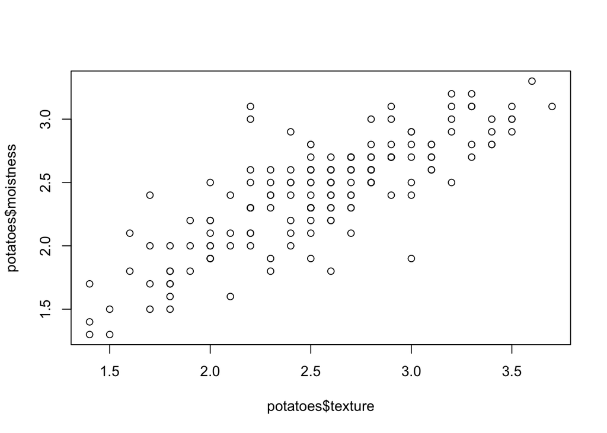

```r
# Plot texture (x) and moistness (y) of potatoes
plot(potatoes$texture, potatoes$moistness)
```

## Dedicated classes

```r
potatoes <- fread("data/potatoes.csv")
class(potatoes)
```

```
## [1] "data.table" "data.frame"
```

```r
potatoes <- read_csv("data/potatoes.csv")
class(potatoes)
```

```
## [1] "tbl_df"     "tbl"        "data.frame"
```

- The classes of the object loaded by `data.table` and `readr` are different

# Importing Excel Data

## First, create the urban popultion datasets used in course

### Gapminder urban population dataset notes

- They use an excel workbook in the datacamp course that they have modified from the gapminder dataset
- On gapminder there is an excel file with urban population data by year, but its all in one worksheet, not split into 3 worksheets.
- Also there is a lot of info in the other worksheets
- I want to recreate the file they use in the class but need some getting data and excel connection skills…
- Luckily, everything I need to do here is covered later in this class and the next importing data class.: )

### Which excel package to use

- There are 3 excel packages covered in this course, `gdata`, `readxl`, and `XLConnect`
  - `gdata` can load files directly from the web, which is nice, but only xls. The gaminder file I need is xlsx
  - `readxl` could work but requires I download the file first. This is fine, but ultimately I need to create worksheets and with portions of the data and save it off. This package is just for reading data in.
  - `XLConnect` is the package I really need to connect and change the worksheet I think.

### R and Java Issues with XLConnect

- These are worth noting because its probably a common problem
- I had rjava issues when trying to load the `XLConnect` library
- First I got an error when loading the libary becasue I did not have java installed on my new mac
  - macs don’t come with java anymore.
  - I installed java from [here](http://www.oracle.com/technetwork/java/javase/downloads/jdk8-downloads-2133151.html)
- Then, I got this error when loading the library…

  ```
  Error: package or namespace load failed for ‘XLConnectJars’:
   .onLoad failed in loadNamespace() for 'rJava', details:
    call: dyn.load(file, DLLpath = DLLpath, ...)
    error: unable to load shared object '/Library/Frameworks/R.framework/Versions/3.4/Resources/library/rJava/libs/rJava.so':
    dlopen(/Library/Frameworks/R.framework/Versions/3.4/Resources/library/rJava/libs/rJava.so, 6): Library not loaded: @rpath/libjvm.dylib
    Referenced from: /Library/Frameworks/R.framework/Versions/3.4/Resources/library/rJava/libs/rJava.so
    Reason: image not found
  ```

- Gross! I know. I googled the error and found a solution on SO
  - Just needed to symlink the java execution path to usr/local/lib so R can run java
  - At least I think thats what its doing : )
- I ran this line of code in the terminal and then the library loaded and worked
  - `sudo ln -f -s $(/usr/libexec/java_home)/jre/lib/server/libjvm.dylib /usr/local/lib`
  - found the answer [here](https://stackoverflow.com/a/31039105/2029832)
- But there was one more problem… I got that same error when trying to run the code with the knitr button.
  - Seriously!
  - I found an answer on SO [here](https://stackoverflow.com/a/44599071/2029832)
  - Throwing this line in the code before loading the library lets the knitr button work
  - This seems pretty gross, but for now it will have to do, so I can move forward with the real learning

    ```
    dyn.load('/Library/Java/JavaVirtualMachines/jdk1.8.0[YOURVERSIONHERE].jdk/Contents/Home/jre/lib/server/libjvm.dylib')
    ```

- Important side note:
  - Issues like this are actually farily common when working with packages that use java or connect to databases or do anything external to R.
  - There is a lot going on under the hood.
  - Sometimes using R packages is kinda like driving a car. Sometimes cars have issues
  - Knowing the command line and devops skills needed to fix this car is something you may or may not want to invest in.
  - If you are at a company with tons of smart software developers and devops engineers, you can probably always get help to get ‘your car fixed’ and get going again on your data science project.
  - But if you are at a startup, working or your own project, or pushing data science forward in a company without devops expertise, you will likely need some level of devops skills to get your projects unstuck at times.
  - If you get stuck, and don’t have the skills or access to someone with the skills to help , you can really spins some weheels and be stuck for a long time and it will be very frustrating.

### Get the file

```r
## Download and load urban pop excel file
url_urban_pop <- "http://docs.google.com/spreadsheet/pub?key=pyj6tScZqmEfH89V6UQhpZA&output=xlsx"
download.file(url_urban_pop, "data/urban_pop_orig.xlsx")
```

### Get and crunch data from original urban pop file

```r
my_book <- loadWorkbook('data/urban_pop_orig.xlsx')

# List the sheets in my_book
getSheets(my_book)
```

```
## [1] "Data"      "About"     "Footnotes" "Settings"  "Download"  "v"
```

```r
## These are the worksheets I want
## "1960-1966" "1967-1974" "1975-2011"

# Get the data sheet with all the ... data
data <- readWorksheet(my_book, sheet='Data')

# I like to use stringr instead of gsub functions
col_names <- colnames(data) %>%
  str_replace("Urban.population","country") %>%
  str_replace("^X","")
col_names
```

```
##  [1] "country" "1960"    "1961"    "1962"    "1963"    "1964"    "1965"
##  [8] "1966"    "1967"    "1968"    "1969"    "1970"    "1971"    "1972"
## [15] "1973"    "1974"    "1975"    "1976"    "1977"    "1978"    "1979"
## [22] "1980"    "1981"    "1982"    "1983"    "1984"    "1985"    "1986"
## [29] "1987"    "1988"    "1989"    "1990"    "1991"    "1992"    "1993"
## [36] "1994"    "1995"    "1996"    "1997"    "1998"    "1999"    "2000"
## [43] "2001"    "2002"    "2003"    "2004"    "2005"    "2006"    "2007"
## [50] "2008"    "2009"    "2010"    "2011"
```

```r
# Set the cleaned column names
colnames(data) <- col_names

data1 <- data[,c("country",c(1960:1966))]
data2 <- data[,c("country",c(1967:1974))]
data3 <- data[,c("country",c(1975:2011))]

### Save new urban pop xlsx file with and without column names
## Now create the 3 sheets and add the data in each
createSheet(my_book,"1960-1966")
createSheet(my_book,"1967-1974")
createSheet(my_book,"1975-2011")

writeWorksheet(my_book, data1, "1960-1966")
writeWorksheet(my_book, data2, "1967-1974")
writeWorksheet(my_book, data3, "1975-2011")

getSheets(my_book)
```

```
## [1] "Data"      "About"     "Footnotes" "Settings"  "Download"  "v"
## [7] "1960-1966" "1967-1974" "1975-2011"
```

```r
## Get rid of the other sheets
removeSheet(my_book, sheet=c("Data","About","Footnotes","Settings","Download","v"))

getSheets(my_book)
```

```
## [1] "1960-1966" "1967-1974" "1975-2011"
```

```r
## save this off as the file just like in the course
saveWorkbook(my_book, "data/urbanpop.xlsx")

## Do it again with no column names
writeWorksheet(my_book, data1, "1960-1966", header=F)
writeWorksheet(my_book, data2, "1967-1974", header=F)
writeWorksheet(my_book, data3, "1975-2011", header=F)

saveWorkbook(my_book, "data/urbanpop_nonames.xlsx")

dir('data/')
```

```
## [1] "hotdogs.txt"           "potatoes.csv"          "potatoes.txt"
## [4] "swimming_pools.csv"    "urban_pop_orig.xlsx"   "urbanpop_nonames.xlsx"
## [7] "urbanpop.xlsx"
```

### create urban pop xls file

```r
## I can repeat the process to create the urbanpop.xls file
## But I need to start from scratch and create the workbook as an xls file to begin with
## If I try to use the xlsx workbbok it will be corrupted and not load correctly later

my_book <- loadWorkbook('data/urbanpop.xls', create=T)

createSheet(my_book,"1960-1966")
createSheet(my_book,"1967-1974")
createSheet(my_book,"1975-2011")

writeWorksheet(my_book, data1, "1960-1966")
writeWorksheet(my_book, data2, "1967-1974")
writeWorksheet(my_book, data3, "1975-2011")

saveWorkbook(my_book, "data/urbanpop.xls")

dir('data/')
```

```
## [1] "hotdogs.txt"           "potatoes.csv"          "potatoes.txt"
## [4] "swimming_pools.csv"    "urban_pop_orig.xlsx"   "urbanpop_nonames.xlsx"
## [7] "urbanpop.xls"          "urbanpop.xlsx"
```

- Okay that all worked pretty smooth.
- I had some trouble with making the xls file at first but figured out I needed to create it from scratch
- Now I can do all the exercises for loading excel files on some actual data.
- Also I feel pretty comfortable now creating any excel file I need in the future.

## readxl(1)

- excel_sheets() list different sheets
- read_excel() actually import data into R

## List the sheets of an Excel file

```r
# the readxl package is already loaded

# Print out the names of both spreadsheets
excel_sheets("data/urbanpop.xlsx")
```

```
## [1] "1960-1966" "1967-1974" "1975-2011"
```

## Import an Excel sheet

```r
# Read the sheets, one by one
pop_1 <- read_excel("data/urbanpop.xlsx", sheet = 1)
pop_2 <- read_excel("data/urbanpop.xlsx", sheet = 2)
pop_3 <- read_excel("data/urbanpop.xlsx", sheet = 3)

# Put pop_1, pop_2 and pop_3 in a list: pop_list
pop_list <- list(pop_1, pop_2, pop_3)

# Display the structure of pop_list
str(pop_list)
```

```
## List of 3
##  $ :Classes 'tbl_df', 'tbl' and 'data.frame':    273 obs. of  8 variables:
##   ..$ country: chr [1:273] "Abkhazia" "Afghanistan" "Akrotiri and Dhekelia" "Albania" ...
##   ..$ 1960   : num [1:273] NA 769308 NA 494443 3293999 ...
##   ..$ 1961   : num [1:273] NA 814923 NA 511803 3515148 ...
##   ..$ 1962   : num [1:273] NA 858522 NA 529439 3739963 ...
##   ..$ 1963   : num [1:273] NA 903914 NA 547377 3973289 ...
##   ..$ 1964   : num [1:273] NA 951226 NA 565572 4220987 ...
##   ..$ 1965   : num [1:273] NA 1000582 NA 583983 4488176 ...
##   ..$ 1966   : num [1:273] NA 1058743 NA 602512 4649105 ...
##  $ :Classes 'tbl_df', 'tbl' and 'data.frame':    273 obs. of  9 variables:
##   ..$ country: chr [1:273] "Abkhazia" "Afghanistan" "Akrotiri and Dhekelia" "Albania" ...
##   ..$ 1967   : num [1:273] NA 1119067 NA 621180 4826104 ...
##   ..$ 1968   : num [1:273] NA 1182159 NA 639964 5017299 ...
##   ..$ 1969   : num [1:273] NA 1248901 NA 658853 5219332 ...
##   ..$ 1970   : num [1:273] NA 1319849 NA 677839 5429743 ...
##   ..$ 1971   : num [1:273] NA 1409001 NA 698932 5619042 ...
##   ..$ 1972   : num [1:273] NA 1502402 NA 720207 5815734 ...
##   ..$ 1973   : num [1:273] NA 1598835 NA 741681 6020647 ...
##   ..$ 1974   : num [1:273] NA 1696445 NA 763385 6235114 ...
##  $ :Classes 'tbl_df', 'tbl' and 'data.frame':    273 obs. of  38 variables:
##   ..$ country: chr [1:273] "Abkhazia" "Afghanistan" "Akrotiri and Dhekelia" "Albania" ...
##   ..$ 1975   : num [1:273] NA 1793266 NA 785350 6460138 ...
##   ..$ 1976   : num [1:273] NA 1905033 NA 807990 6774099 ...
##   ..$ 1977   : num [1:273] NA 2021308 NA 830959 7102902 ...
##   ..$ 1978   : num [1:273] NA 2142248 NA 854262 7447728 ...
##   ..$ 1979   : num [1:273] NA 2268015 NA 877898 7810073 ...
##   ..$ 1980   : num [1:273] NA 2398775 NA 901884 8190772 ...
##   ..$ 1981   : num [1:273] NA 2493265 NA 927224 8637724 ...
##   ..$ 1982   : num [1:273] NA 2590846 NA 952447 9105820 ...
##   ..$ 1983   : num [1:273] NA 2691612 NA 978476 9591900 ...
##   ..$ 1984   : num [1:273] NA 2795656 NA 1006613 10091289 ...
##   ..$ 1985   : num [1:273] NA 2903078 NA 1037541 10600112 ...
##   ..$ 1986   : num [1:273] NA 3006983 NA 1072365 11101757 ...
##   ..$ 1987   : num [1:273] NA 3113957 NA 1109954 11609104 ...
##   ..$ 1988   : num [1:273] NA 3224082 NA 1146633 12122941 ...
##   ..$ 1989   : num [1:273] NA 3337444 NA 1177286 12645263 ...
##   ..$ 1990   : num [1:273] NA 3454129 NA 1198293 13177079 ...
##   ..$ 1991   : num [1:273] NA 3617842 NA 1215445 13708813 ...
##   ..$ 1992   : num [1:273] NA 3788685 NA 1222544 14248297 ...
##   ..$ 1993   : num [1:273] NA 3966956 NA 1222812 14789176 ...
##   ..$ 1994   : num [1:273] NA 4152960 NA 1221364 15322651 ...
##   ..$ 1995   : num [1:273] NA 4347018 NA 1222234 15842442 ...
##   ..$ 1996   : num [1:273] NA 4531285 NA 1228760 16395553 ...
##   ..$ 1997   : num [1:273] NA 4722603 NA 1238090 16935451 ...
##   ..$ 1998   : num [1:273] NA 4921227 NA 1250366 17469200 ...
##   ..$ 1999   : num [1:273] NA 5127421 NA 1265195 18007937 ...
##   ..$ 2000   : num [1:273] NA 5341456 NA 1282223 18560597 ...
##   ..$ 2001   : num [1:273] NA 5564492 NA 1315690 19198872 ...
##   ..$ 2002   : num [1:273] NA 5795940 NA 1352278 19854835 ...
##   ..$ 2003   : num [1:273] NA 6036100 NA 1391143 20529356 ...
##   ..$ 2004   : num [1:273] NA 6285281 NA 1430918 21222198 ...
##   ..$ 2005   : num [1:273] NA 6543804 NA 1470488 21932978 ...
##   ..$ 2006   : num [1:273] NA 6812538 NA 1512255 22625052 ...
##   ..$ 2007   : num [1:273] NA 7091245 NA 1553491 23335543 ...
##   ..$ 2008   : num [1:273] NA 7380272 NA 1594351 24061749 ...
##   ..$ 2009   : num [1:273] NA 7679982 NA 1635262 24799591 ...
##   ..$ 2010   : num [1:273] NA 7990746 NA 1676545 25545622 ...
##   ..$ 2011   : num [1:273] NA 8316976 NA 1716842 26216968 ...
```

## Reading a workbook

```r
# Read all Excel sheets with lapply(): pop_list
pop_list <- lapply(
  excel_sheets("data/urbanpop.xlsx"),
  read_excel,
  path = "data/urbanpop.xlsx"
  )

# Display the structure of pop_list
str(pop_list)
```

```
## List of 3
##  $ :Classes 'tbl_df', 'tbl' and 'data.frame':    273 obs. of  8 variables:
##   ..$ country: chr [1:273] "Abkhazia" "Afghanistan" "Akrotiri and Dhekelia" "Albania" ...
##   ..$ 1960   : num [1:273] NA 769308 NA 494443 3293999 ...
##   ..$ 1961   : num [1:273] NA 814923 NA 511803 3515148 ...
##   ..$ 1962   : num [1:273] NA 858522 NA 529439 3739963 ...
##   ..$ 1963   : num [1:273] NA 903914 NA 547377 3973289 ...
##   ..$ 1964   : num [1:273] NA 951226 NA 565572 4220987 ...
##   ..$ 1965   : num [1:273] NA 1000582 NA 583983 4488176 ...
##   ..$ 1966   : num [1:273] NA 1058743 NA 602512 4649105 ...
##  $ :Classes 'tbl_df', 'tbl' and 'data.frame':    273 obs. of  9 variables:
##   ..$ country: chr [1:273] "Abkhazia" "Afghanistan" "Akrotiri and Dhekelia" "Albania" ...
##   ..$ 1967   : num [1:273] NA 1119067 NA 621180 4826104 ...
##   ..$ 1968   : num [1:273] NA 1182159 NA 639964 5017299 ...
##   ..$ 1969   : num [1:273] NA 1248901 NA 658853 5219332 ...
##   ..$ 1970   : num [1:273] NA 1319849 NA 677839 5429743 ...
##   ..$ 1971   : num [1:273] NA 1409001 NA 698932 5619042 ...
##   ..$ 1972   : num [1:273] NA 1502402 NA 720207 5815734 ...
##   ..$ 1973   : num [1:273] NA 1598835 NA 741681 6020647 ...
##   ..$ 1974   : num [1:273] NA 1696445 NA 763385 6235114 ...
##  $ :Classes 'tbl_df', 'tbl' and 'data.frame':    273 obs. of  38 variables:
##   ..$ country: chr [1:273] "Abkhazia" "Afghanistan" "Akrotiri and Dhekelia" "Albania" ...
##   ..$ 1975   : num [1:273] NA 1793266 NA 785350 6460138 ...
##   ..$ 1976   : num [1:273] NA 1905033 NA 807990 6774099 ...
##   ..$ 1977   : num [1:273] NA 2021308 NA 830959 7102902 ...
##   ..$ 1978   : num [1:273] NA 2142248 NA 854262 7447728 ...
##   ..$ 1979   : num [1:273] NA 2268015 NA 877898 7810073 ...
##   ..$ 1980   : num [1:273] NA 2398775 NA 901884 8190772 ...
##   ..$ 1981   : num [1:273] NA 2493265 NA 927224 8637724 ...
##   ..$ 1982   : num [1:273] NA 2590846 NA 952447 9105820 ...
##   ..$ 1983   : num [1:273] NA 2691612 NA 978476 9591900 ...
##   ..$ 1984   : num [1:273] NA 2795656 NA 1006613 10091289 ...
##   ..$ 1985   : num [1:273] NA 2903078 NA 1037541 10600112 ...
##   ..$ 1986   : num [1:273] NA 3006983 NA 1072365 11101757 ...
##   ..$ 1987   : num [1:273] NA 3113957 NA 1109954 11609104 ...
##   ..$ 1988   : num [1:273] NA 3224082 NA 1146633 12122941 ...
##   ..$ 1989   : num [1:273] NA 3337444 NA 1177286 12645263 ...
##   ..$ 1990   : num [1:273] NA 3454129 NA 1198293 13177079 ...
##   ..$ 1991   : num [1:273] NA 3617842 NA 1215445 13708813 ...
##   ..$ 1992   : num [1:273] NA 3788685 NA 1222544 14248297 ...
##   ..$ 1993   : num [1:273] NA 3966956 NA 1222812 14789176 ...
##   ..$ 1994   : num [1:273] NA 4152960 NA 1221364 15322651 ...
##   ..$ 1995   : num [1:273] NA 4347018 NA 1222234 15842442 ...
##   ..$ 1996   : num [1:273] NA 4531285 NA 1228760 16395553 ...
##   ..$ 1997   : num [1:273] NA 4722603 NA 1238090 16935451 ...
##   ..$ 1998   : num [1:273] NA 4921227 NA 1250366 17469200 ...
##   ..$ 1999   : num [1:273] NA 5127421 NA 1265195 18007937 ...
##   ..$ 2000   : num [1:273] NA 5341456 NA 1282223 18560597 ...
##   ..$ 2001   : num [1:273] NA 5564492 NA 1315690 19198872 ...
##   ..$ 2002   : num [1:273] NA 5795940 NA 1352278 19854835 ...
##   ..$ 2003   : num [1:273] NA 6036100 NA 1391143 20529356 ...
##   ..$ 2004   : num [1:273] NA 6285281 NA 1430918 21222198 ...
##   ..$ 2005   : num [1:273] NA 6543804 NA 1470488 21932978 ...
##   ..$ 2006   : num [1:273] NA 6812538 NA 1512255 22625052 ...
##   ..$ 2007   : num [1:273] NA 7091245 NA 1553491 23335543 ...
##   ..$ 2008   : num [1:273] NA 7380272 NA 1594351 24061749 ...
##   ..$ 2009   : num [1:273] NA 7679982 NA 1635262 24799591 ...
##   ..$ 2010   : num [1:273] NA 7990746 NA 1676545 25545622 ...
##   ..$ 2011   : num [1:273] NA 8316976 NA 1716842 26216968 ...
```

## The col_names argument

```r
# Import the the first Excel sheet of urbanpop_nonames.xlsx (R gives names): pop_a
pop_a <- read_excel("data/urbanpop_nonames.xlsx", sheet=1, col_names = F)

# Import the the first Excel sheet of urbanpop_nonames.xlsx (specify col_names): pop_b
cols <- c("country", paste0("year_", 1960:1966))

pop_b <- read_excel("data/urbanpop_nonames.xlsx", sheet=1, col_names=cols)

# Print the summary of pop_a
summary(pop_a)
```

```
##      X__1                X__2                X__3
##  Length:274         Min.   :     3378   Min.   :     1028
##  Class :character   1st Qu.:    90220   1st Qu.:    70644
##  Mode  :character   Median :   561636   Median :   570159
##                     Mean   :  4963530   Mean   :  4991613
##                     3rd Qu.:  3024372   3rd Qu.:  2807280
##                     Max.   :126469700   Max.   :129268133
##                     NA's   :75          NA's   :65
##       X__4                X__5                X__6
##  Min.   :     1090   Min.   :     1154   Min.   :     1218
##  1st Qu.:    74974   1st Qu.:    81870   1st Qu.:    84953
##  Median :   593968   Median :   619331   Median :   645262
##  Mean   :  5141592   Mean   :  5303711   Mean   :  5468966
##  3rd Qu.:  2948396   3rd Qu.:  3148941   3rd Qu.:  3296444
##  Max.   :131974143   Max.   :134599886   Max.   :137205240
##  NA's   :65          NA's   :65          NA's   :65
##       X__7                X__8
##  Min.   :     1281   Min.   :     1349
##  1st Qu.:    88633   1st Qu.:    93638
##  Median :   679109   Median :   735139
##  Mean   :  5637394   Mean   :  5790281
##  3rd Qu.:  3317422   3rd Qu.:  3418036
##  Max.   :139663053   Max.   :141962708
##  NA's   :65          NA's   :65
```

```r
# Print the summary of pop_b
summary(pop_b)
```

```
##    country            year_1960           year_1961
##  Length:274         Min.   :     3378   Min.   :     1028
##  Class :character   1st Qu.:    90220   1st Qu.:    70644
##  Mode  :character   Median :   561636   Median :   570159
##                     Mean   :  4963530   Mean   :  4991613
##                     3rd Qu.:  3024372   3rd Qu.:  2807280
##                     Max.   :126469700   Max.   :129268133
##                     NA's   :75          NA's   :65
##    year_1962           year_1963           year_1964
##  Min.   :     1090   Min.   :     1154   Min.   :     1218
##  1st Qu.:    74974   1st Qu.:    81870   1st Qu.:    84953
##  Median :   593968   Median :   619331   Median :   645262
##  Mean   :  5141592   Mean   :  5303711   Mean   :  5468966
##  3rd Qu.:  2948396   3rd Qu.:  3148941   3rd Qu.:  3296444
##  Max.   :131974143   Max.   :134599886   Max.   :137205240
##  NA's   :65          NA's   :65          NA's   :65
##    year_1965           year_1966
##  Min.   :     1281   Min.   :     1349
##  1st Qu.:    88633   1st Qu.:    93638
##  Median :   679109   Median :   735139
##  Mean   :  5637394   Mean   :  5790281
##  3rd Qu.:  3317422   3rd Qu.:  3418036
##  Max.   :139663053   Max.   :141962708
##  NA's   :65          NA's   :65
```

## the skip argument

```r
# Import the second sheet of urbanpop.xlsx, skipping the first 21 rows: urbanpop_sel
urbanpop_sel <- read_excel("data/urbanpop.xlsx", sheet=2, skip=21, col_names=F)

# Print out the first observation from urbanpop_sel
# I'm showing 5. We can see that we are on the countries starting with B
urbanpop_sel[1:5,]
```

```
## # A tibble: 5 x 9
##      X__1       X__2       X__3      X__4       X__5       X__6       X__7
##     <chr>      <dbl>      <dbl>     <dbl>      <dbl>      <dbl>      <dbl>
## 1 Belarus 3556447.88 3696854.38 3838002.9 3978504.00 4132163.53 4286800.60
## 2 Belgium 8950504.31 8999365.83 9038505.6 9061056.85 9089909.02 9137945.57
## 3  Belize   58790.24   59711.73   60492.2   61141.33   61839.91   62403.29
## 4   Benin  382022.12  411859.45  443013.1  475611.38  515819.53  557937.60
## 5 Bermuda   52000.00   53000.00   54000.0   55000.00   54600.00   54200.00
## # ... with 2 more variables: X__8 <dbl>, X__9 <dbl>
```

## gdata

- written in pearl
- wraps `read.table` and makes all of its arguments available
- Its pretty slow. It converts everything to csv then reads it in
- Its recommended to use readxl, but this is still under development
- gdata has been around for a while and is stable.

## Import a local file

```r
# gdata library is already loaded

# Import the second sheet of urbanpop.xls: urban_pop
urban_pop <- read.xls("data/urbanpop.xls", sheet=2)

# Print the first 11 observations using head()
head(urban_pop,11)
```

```
##                  country       X1967       X1968       X1969       X1970
## 1               Abkhazia          NA          NA          NA          NA
## 2            Afghanistan  1119067.20  1182159.06  1248900.79  1319848.78
## 3  Akrotiri and Dhekelia          NA          NA          NA          NA
## 4                Albania   621179.85   639964.46   658853.12   677839.12
## 5                Algeria  4826104.22  5017298.60  5219331.87  5429743.08
## 6         American Samoa    17348.66    17995.51    18618.68    19206.39
## 7                Andorra    15439.62    16726.99    18088.32    19528.96
## 8                 Angola   757496.32   798459.26   841261.96   886401.63
## 9               Anguilla          NA          NA          NA          NA
## 10   Antigua and Barbuda    22086.25    22149.39    22182.92    22180.87
## 11             Argentina 17753280.98 18124103.64 18510462.30 18918072.79
##          X1971       X1972       X1973       X1974
## 1           NA          NA          NA          NA
## 2   1409001.09  1502401.79  1598835.45  1696444.83
## 3           NA          NA          NA          NA
## 4    698932.25   720206.57   741681.04   763385.45
## 5   5619041.53  5815734.49  6020647.35  6235114.38
## 6     19752.02    20262.67    20741.97    21194.38
## 7     20928.73    22405.84    23937.05    25481.98
## 8    955010.09  1027397.35  1103829.78  1184486.23
## 9           NA          NA          NA          NA
## 10    22560.87    22907.76    23221.29    23502.92
## 11 19329718.16 19763078.00 20211424.85 20664728.90
```

## read.xls() wraps around read.table()

```r
# Column names for urban_pop
columns <- c("country", paste0("year_", 1967:1974))

# Finish the read.xls call
urban_pop <- read.xls("data/urbanpop.xls", sheet = 2,
                      skip = 50, header = F, stringsAsFactors = F,
                      col.names = columns)

# Print first 10 observation of urban_pop
head(urban_pop,10)
```

```
##             country year_1967 year_1968 year_1969 year_1970 year_1971
## 1  Congo, Dem. Rep. 5161472.5 5475208.0 5802068.8 6140903.7 6282833.7
## 2       Congo, Rep.  450669.8  473335.2  497210.7  522406.6  549789.4
## 3           Cook Is        NA        NA        NA        NA        NA
## 4        Costa Rica  621785.8  649916.4  678253.9  706798.6  733545.9
## 5     Cote d'Ivoire 1243350.1 1330719.3 1424438.5 1525425.2 1638738.0
## 6           Croatia 1608233.0 1663050.6 1717607.0 1773045.6 1826421.7
## 7              Cuba 4927341.2 5032013.6 5137260.2 5244278.6 5407254.3
## 8            Cyprus  231929.7  237831.4  243983.3  250164.5  261213.2
## 9    Czech Republic 6204409.9 6266304.5 6326369.0 6348794.9 6437055.2
## 10   Czechoslovakia        NA        NA        NA        NA        NA
##    year_1972 year_1973 year_1974
## 1  6425372.3 6570538.5 6721175.0
## 2   578639.8  608850.4  640236.4
## 3         NA        NA        NA
## 4   760430.8  787918.3  816658.8
## 5  1760508.3 1891241.0 2031395.3
## 6  1879427.8 1932436.1 1984975.8
## 7  5572975.4 5738230.5 5898512.3
## 8   272408.0  283774.9  295379.8
## 9  6572632.3 6718465.5 6873458.2
## 10        NA        NA        NA
```

## Work that Excel data!

```r
# Add code to import data from all three sheets in urbanpop.xls
path <- "data/urbanpop.xls"
urban_sheet1 <- read.xls(path, sheet = 1, stringsAsFactors = FALSE)
urban_sheet2 <- read.xls(path, sheet = 2, stringsAsFactors = FALSE)
urban_sheet3 <- read.xls(path, sheet = 3, stringsAsFactors = FALSE)

# Extend the cbind() call to include urban_sheet3: urban
urban <- cbind(urban_sheet1, urban_sheet2[-1], urban_sheet3[-1])

# Remove all rows with NAs from urban: urban_clean
urban_clean <- na.omit(urban)

# Print out a summary of urban_clean
# Shortening the output to the first 5 columns
summary(urban_clean[, 1:5])
```

```
##    country              X1960               X1961
##  Length:197         Min.   :     3378   Min.   :     3433
##  Class :character   1st Qu.:    87735   1st Qu.:    92905
##  Mode  :character   Median :   599714   Median :   630788
##                     Mean   :  5012388   Mean   :  5282488
##                     3rd Qu.:  3130085   3rd Qu.:  3155370
##                     Max.   :126469700   Max.   :129268133
##      X1962               X1963
##  Min.   :     3481   Min.   :     3532
##  1st Qu.:    98331   1st Qu.:   104988
##  Median :   659464   Median :   704989
##  Mean   :  5440972   Mean   :  5612312
##  3rd Qu.:  3250211   3rd Qu.:  3416490
##  Max.   :131974143   Max.   :134599886
```

# Reproducible Excel work with XLConnect

## Reading sheets

- bridge between excel and R
- uses java, installing package can have its difficulties
  - I had some for sure
- works with xlsx and xls files
- They even note that you will probably need to google errors when trying to install this package. : )

## Connect to a workbook

```r
# The XLConnect package is already loaded

# Build connection to urbanpop.xlsx: my_book
my_book <- loadWorkbook('data/urbanpop.xlsx')

# Print out the class of my_book
class(my_book)
```

```
## [1] "workbook"
## attr(,"package")
## [1] "XLConnect"
```

## List and read Excel sheets

```r
# Build connection to urbanpop.xlsx
my_book <- loadWorkbook("data/urbanpop.xlsx")

# List the sheets in my_book
getSheets(my_book)
```

```
## [1] "1960-1966" "1967-1974" "1975-2011"
```

```r
# Import the second sheet in my_book
head(readWorksheet(my_book, sheet=2),10)
```

```
##                  country      X1967      X1968      X1969      X1970
## 1               Abkhazia         NA         NA         NA         NA
## 2            Afghanistan 1119067.20 1182159.06 1248900.79 1319848.78
## 3  Akrotiri and Dhekelia         NA         NA         NA         NA
## 4                Albania  621179.85  639964.46  658853.12  677839.12
## 5                Algeria 4826104.22 5017298.60 5219331.87 5429743.08
## 6         American Samoa   17348.66   17995.51   18618.68   19206.39
## 7                Andorra   15439.62   16726.99   18088.32   19528.96
## 8                 Angola  757496.32  798459.26  841261.96  886401.63
## 9               Anguilla         NA         NA         NA         NA
## 10   Antigua and Barbuda   22086.25   22149.39   22182.92   22180.87
##         X1971      X1972      X1973      X1974
## 1          NA         NA         NA         NA
## 2  1409001.09 1502401.79 1598835.45 1696444.83
## 3          NA         NA         NA         NA
## 4   698932.25  720206.57  741681.04  763385.45
## 5  5619041.53 5815734.49 6020647.35 6235114.38
## 6    19752.02   20262.67   20741.97   21194.38
## 7    20928.73   22405.84   23937.05   25481.98
## 8   955010.09 1027397.35 1103829.78 1184486.23
## 9          NA         NA         NA         NA
## 10   22560.87   22907.76   23221.29   23502.92
```

## Customize readWorksheet

```r
# Build connection to urbanpop.xlsx
my_book <- loadWorkbook("data/urbanpop.xlsx")

# Import columns 3, 4, and 5 from second sheet in my_book: urbanpop_sel
urbanpop_sel <- readWorksheet(my_book, sheet = 2, startCol=3, endCol=5)

# Import first column from second sheet in my_book: countries
countries <- readWorksheet(my_book, sheet = 2, startCol=1, endCol=1)

## For some reason these have different number of rows
str(urbanpop_sel)
```

```
## 'data.frame':    260 obs. of  3 variables:
##  $ X1968: num  NA 1182159 NA 639964 5017299 ...
##  $ X1969: num  NA 1248901 NA 658853 5219332 ...
##  $ X1970: num  NA 1319849 NA 677839 5429743 ...
```

```r
str(countries)
```

```
## 'data.frame':    273 obs. of  1 variable:
##  $ country: chr  "Abkhazia" "Afghanistan" "Akrotiri and Dhekelia" "Albania" ...
```

```r
## Welp, lets add some rows so we can cbind
extra_rows <- rep(NA, nrow(countries) - nrow(urbanpop_sel))

df_extra_rows <- data.frame(x1 = extra_rows,
                            x2 = extra_rows,
                            x3 = extra_rows)

colnames(df_extra_rows) <- colnames(urbanpop_sel)

urbanpop_sel_2 <- rbind(urbanpop_sel,df_extra_rows)

str(urbanpop_sel_2)
```

```
## 'data.frame':    273 obs. of  3 variables:
##  $ X1968: num  NA 1182159 NA 639964 5017299 ...
##  $ X1969: num  NA 1248901 NA 658853 5219332 ...
##  $ X1970: num  NA 1319849 NA 677839 5429743 ...
```

```r
# cbind() urbanpop_sel and countries together: selection
selection <- cbind(countries, urbanpop_sel_2)
str(selection)
```

```
## 'data.frame':    273 obs. of  4 variables:
##  $ country: chr  "Abkhazia" "Afghanistan" "Akrotiri and Dhekelia" "Albania" ...
##  $ X1968  : num  NA 1182159 NA 639964 5017299 ...
##  $ X1969  : num  NA 1248901 NA 658853 5219332 ...
##  $ X1970  : num  NA 1319849 NA 677839 5429743 ...
```

## Adapting sheets

- You can do a lot with XLConnect to change sheets in the workbook
- I go through the basics above when creating the excel datasets needed for these exercises
- But there is a lot of useful functionality for styling cells, working with formulas, arranging cells, and more not covered here
- Check out the [XLConnect vignette](https://cran.r-project.org/web/packages/XLConnect/vignettes/XLConnect.pdf) to go more in depth with this

## Add worksheet

```r
# Build connection to urbanpop.xlsx
my_book <- loadWorkbook("data/urbanpop.xlsx")

# Add a worksheet to my_book, named "data_summary"
createSheet(my_book,"data_summary")

# Use getSheets() on my_book
getSheets(my_book)
```

```
## [1] "1960-1966"    "1967-1974"    "1975-2011"    "data_summary"
```

## Populate worksheet

```r
# Build connection to urbanpop.xlsx
my_book <- loadWorkbook("data/urbanpop.xlsx")

# Add a worksheet to my_book, named "data_summary"
createSheet(my_book, "data_summary")

# Create data frame: summ
sheets <- getSheets(my_book)[1:3]
dims <- sapply(sheets, function(x) dim(readWorksheet(my_book, sheet = x)), USE.NAMES = FALSE)
summ <- data.frame(sheets = sheets,
                   nrows = dims[1, ],
                   ncols = dims[2, ])

# Add data in summ to "data_summary" sheet
writeWorksheet(my_book, summ, "data_summary")


# Save workbook as summary.xlsx
saveWorkbook(my_book, "data/summary.xlsx")

dir('data/')
```

```
## [1] "hotdogs.txt"           "potatoes.csv"          "potatoes.txt"
## [4] "summary.xlsx"          "swimming_pools.csv"    "urban_pop_orig.xlsx"
## [7] "urbanpop_nonames.xlsx" "urbanpop.xls"          "urbanpop.xlsx"
```

## Rename sheets

```r
# Rename "data_summary" sheet to "summary"
renameSheet(my_book, sheet="data_summary", newName="summary")

# Print out sheets of my_book
getSheets(my_book)
```

```
## [1] "1960-1966" "1967-1974" "1975-2011" "summary"
```

```r
# Save workbook to "renamed.xlsx"
saveWorkbook(my_book, "data/renamed.xlsx")

dir('data/')
```

```
##  [1] "hotdogs.txt"           "potatoes.csv"
##  [3] "potatoes.txt"          "renamed.xlsx"
##  [5] "summary.xlsx"          "swimming_pools.csv"
##  [7] "urban_pop_orig.xlsx"   "urbanpop_nonames.xlsx"
##  [9] "urbanpop.xls"          "urbanpop.xlsx"
```

## Removing sheets

```r
# Build connection to renamed.xlsx: my_book
my_book <- loadWorkbook("data/renamed.xlsx")

# Remove the fourth sheet
removeSheet(my_book, sheet="summary")

# Save workbook to "clean.xlsx"
saveWorkbook(my_book, "data/clean.xlsx")

dir('data/')
```

```
##  [1] "clean.xlsx"            "hotdogs.txt"
##  [3] "potatoes.csv"          "potatoes.txt"
##  [5] "renamed.xlsx"          "summary.xlsx"
##  [7] "swimming_pools.csv"    "urban_pop_orig.xlsx"
##  [9] "urbanpop_nonames.xlsx" "urbanpop.xls"
## [11] "urbanpop.xlsx"
```

# Conclusion

- This all seems really handy for a finance department trying to move from excel to R
- Or taking over someone elses old excel sheets and making them more efficient
- Taking data out of an excel sheet is always useful because sometimes thats just where the data is located
- But doing the analysis in R, coded, commented, and reporducible with the power of the hadley verse then putting the results back into whatever worksheet you have is a big win.
- With this you could easily use all of the power of R to replace or enhance anything you have in an excel sheet
- And of course the same applies to any data that you have stored in a flat file.
- In most cases I think presenting the data in a slide show, shiny app or html doc are the best wy to go
- But if the process requires excel sheets and things, than at least you can work in the flow until you create a better one.
- There is always a flow of data and excel may be part of so this is good stuff to know.